# HW3 - Nathan Riley

## Load & Exploratory [1-2]

**1. Plot the series. Label the axes and give it a title.**

```r
realgdp <- read.csv("./Data/realgdp.csv")
head(realgdp)
```

```
##         DATE ND000334Q
## 1 2002-01-01  3501.118
## 2 2002-04-01  3608.496
## 3 2002-07-01  3650.253
## 4 2002-10-01  3712.845
## 5 2003-01-01  3582.767
## 6 2003-04-01  3680.929
```

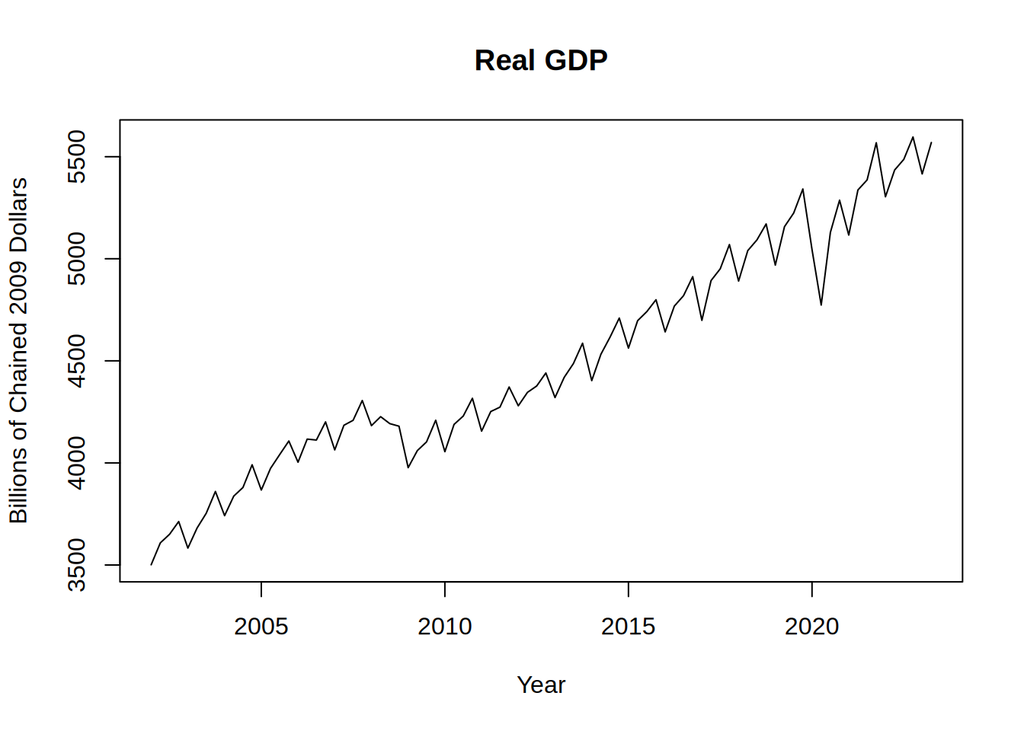

```r
names(realgdp) <- c("Date", "REALGDP")
realgdp.ts <- ts(realgdp$REALGDP, start = c(2002, 1), frequency = 4)

plot(
  realgdp.ts,
  main = "Real GDP",
  ylab = "Billions of Chained 2009 Dollars",
  xlab = "Year"
)
```

**2. Is there seasonality? In what quarter is GDP typically the highest? In what quarter is it typically the lowest?**  
There is seasonality as we can see when it is decomposed.  
It seems that GDP is highest in Q4 every year and lowest in Q1

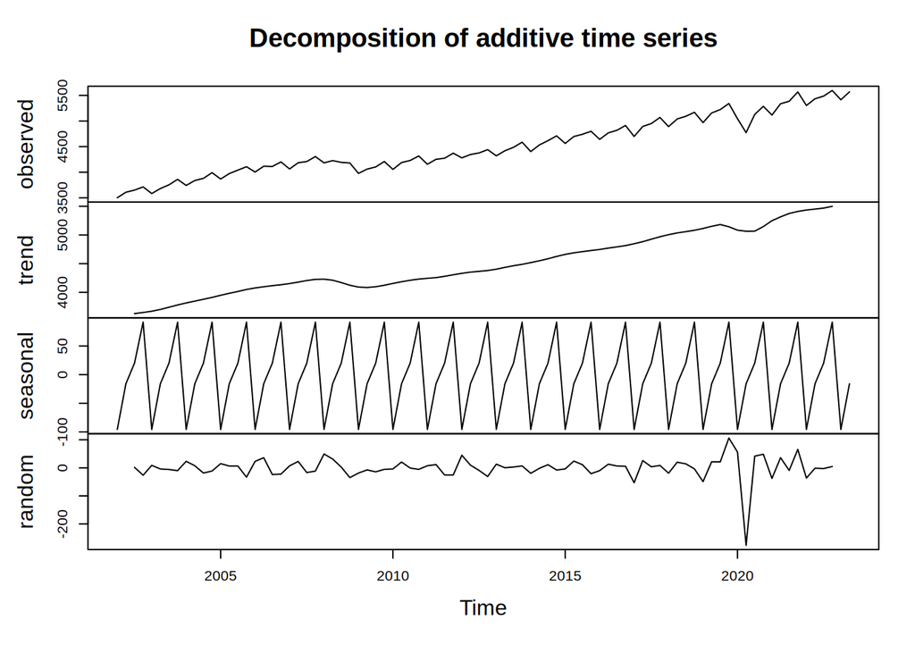

```r
realgdp.dc <- decompose(realgdp.ts)

plot(realgdp.dc)
```

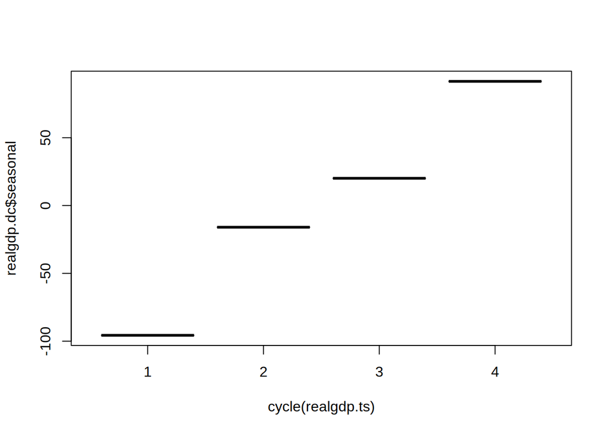

```r
boxplot(realgdp.dc$seasonal ~ cycle(realgdp.ts))
```

## AR [3-5]

**3. Plot the ACF and PACF of the series and interpret. Based on the graphs, how many lags should we use if we fit an AR(p) model to the data?**  
ACF slopes down steadily over time, falling below the threshold at around lag 5/6.  
PACF falls immediately, with a spike just beyond lag 1 that exceeds the threshold and some additional smaller ones later that do not. I would argue that we should use 1 lag since the last significant spike lies just after it.

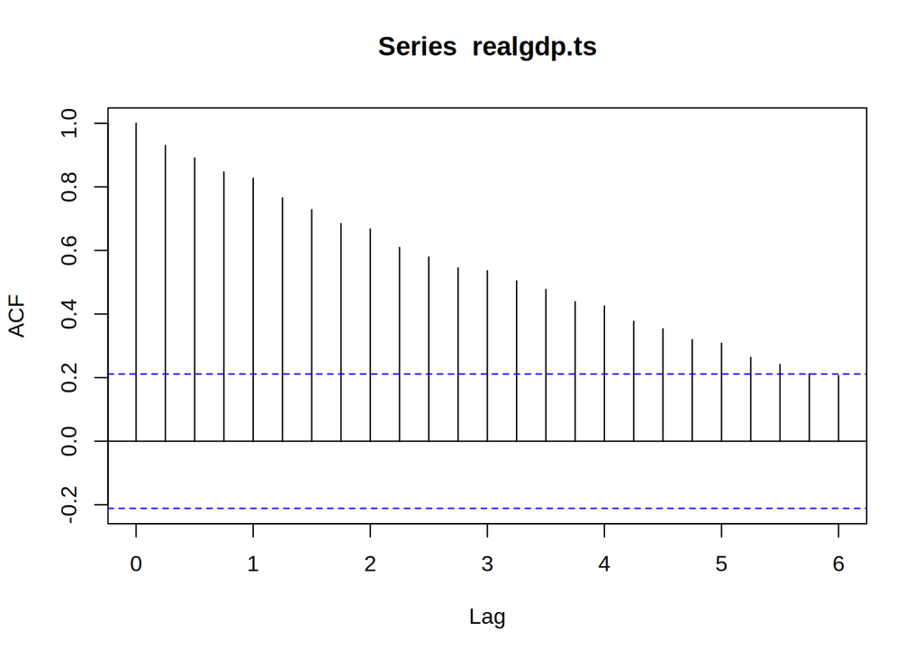

```r
acf(realgdp.ts, lag.max = 24)
```

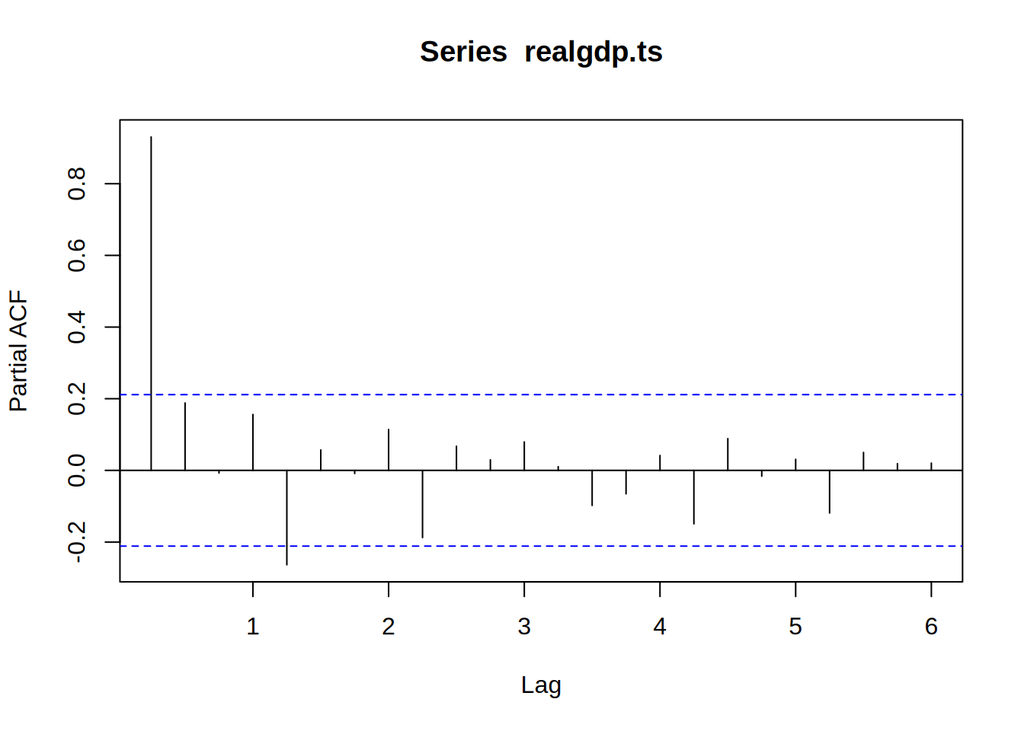

```r
pacf(realgdp.ts, lag.max = 24)
```

**4. Using the “arima” function (with the option method=“ML” for maximum likelihood estimation), manually determine the best AR(p) model for the data, based on the AIC, for all models with 𝑝𝑝 ≤ 6. Show all of your steps in your typed answers. Report the order p, the values of all coefficients, and the AIC for the best model.**

```r
for (p in 0:6) {
  print(
    paste("p=", p, " - ",
      formatC(
        arima(realgdp.ts, order = c(p, 0, 0), method = "ML")$aic,
        digits = 2, format = "f"
      ),
      sep = ""
    ),
    quote = FALSE
  )
}
```

```
## [1] p=0 - 1332.56
## [1] p=1 - 1087.97
## [1] p=2 - 1082.55
## [1] p=3 - 1082.22
## [1] p=4 - 1065.81
## [1] p=5 - 1034.34
## [1] p=6 - 1036.03
```

**Q4: Report the order p, the values of all coefficients, and the AIC for the best model**  
A: The best model I found was p=5 with an aic of 1,034.34.  
The full results are below:

```r
Q4 <- arima(realgdp.ts, order = c(5, 0, 0), method = "ML")
Q4
```

```
##
## Call:
## arima(x = realgdp.ts, order = c(5, 0, 0), method = "ML")
##
## Coefficients:
##          ar1     ar2      ar3     ar4      ar5  intercept
##       0.7689  0.0848  -0.0243  0.7404  -0.5746  4540.0622
## s.e.  0.0878  0.0870   0.0888  0.0881   0.0875   827.3729
##
## sigma^2 estimated as 7658:  log likelihood = -510.17,  aic = 1034.34
```

**5. Analyze the correlogram of the residuals for the best version of the model from #4.**  
*A: It would appear that there is only one line at lag 1 that exceeds the threshold, indicating this is insignificant white noise left over. Arguably, there might be a second line at lag 2, but this still looks like white noise.*

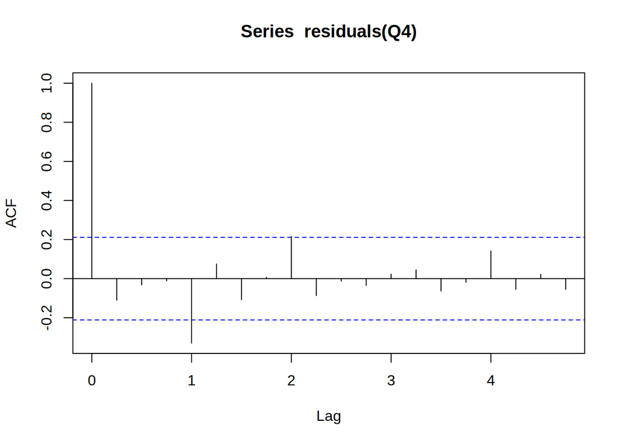

```r
acf(residuals(Q4))
```

## MA [6-7]

**6. Using the “arima” function (with the option method=“ML” for maximum likelihood estimation), manually determine the best MA(q) model for the data, based on the AIC, for all models with 𝑞𝑞 ≤ 12. Show all of your steps in your typed answers. Report the order q, the values of all coefficients, and the AIC for the best model.**

```r
for (q in 0:12) {
  print(
    paste("q=", q, " - ",
      formatC(
        arima(realgdp.ts, order = c(0, 0, q), method = "ML")$aic,
        digits = 2, format = "f"
      ),
      sep = ""
    ),
    quote = FALSE,
  )
}
```

```
## [1] q=0 - 1332.56
## [1] q=1 - 1260.98
## [1] q=2 - 1184.33
## [1] q=3 - 1163.95
## [1] q=4 - 1147.37
## [1] q=5 - 1123.49
## [1] q=6 - 1105.31
## [1] q=7 - 1107.29
## [1] q=8 - 1089.46
## [1] q=9 - 1084.24
## [1] q=10 - 1077.23
## [1] q=11 - 1076.31
## [1] q=12 - 1078.16
```

**Q6: Report the order q, the values of all coefficients, and the AIC for the best model**  
A: The best model I found was q=11 with an aic of 1076.31.  
The full results are below:

```r
Q6 <- arima(realgdp.ts, order = c(0, 0, 11), method = "ML")
Q6
```

```
##
## Call:
## arima(x = realgdp.ts, order = c(0, 0, 11), method = "ML")
##
## Coefficients:
##          ma1     ma2     ma3     ma4     ma5     ma6     ma7     ma8     ma9
##       1.0287  1.1266  1.0485  1.5788  1.3173  1.2704  1.0571  1.4841  0.9279
## s.e.  0.1437  0.1878  0.1833  0.1730  0.2141  0.2541  0.2566  0.2630  0.2219
##         ma10    ma11  intercept
##       0.6371  0.1946  4480.2659
## s.e.  0.1652  0.1143   126.5137
##
## sigma^2 estimated as 9512:  log likelihood = -525.16,  aic = 1076.31
```

**7. Analyze the correlogram of the residuals for the best version of the model from #6.**  
*A: The correlogram has 3 (almost 4) spikes on the year mark, which stick above the threshold. This indicates to me that this is more than white noise.*

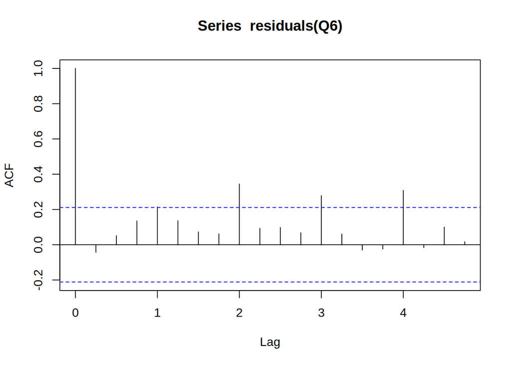

```r
acf(residuals(Q6))
```

## ARMA [8-9]

**8. Use the “auto.arima” function to determine the best ARMA(p,q) model for the data. To get auto.arima to match the results of the “arima” function, use the appropriate values of the “d=…” option and “seasonal=…” option, plus these options: ic=“aic”, approximation=FALSE, trace=TRUE, stepwise=FALSE, and method=“ML”. Report the order (p,q), the values of all coefficients, and the AIC for the best model.**

```r
library(forecast)
Q8 <- auto.arima(realgdp.ts,
  d = 0,
  seasonal = FALSE,
  ic = "aic",
  approximation = FALSE,
  trace = TRUE,
  stepwise = FALSE,
  method = "ML"
)
```

```
##
##  ARIMA(0,0,0)           with zero mean     : 1694.314
##  ARIMA(0,0,0)           with non-zero mean : 1332.563
##  ARIMA(0,0,1)           with zero mean     : 1589.508
##  ARIMA(0,0,1)           with non-zero mean : 1260.983
##  ARIMA(0,0,2)           with zero mean     : Inf
##  ARIMA(0,0,2)           with non-zero mean : 1184.332
##  ARIMA(0,0,3)           with zero mean     : Inf
##  ARIMA(0,0,3)           with non-zero mean : 1163.952
##  ARIMA(0,0,4)           with zero mean     : Inf
##  ARIMA(0,0,4)           with non-zero mean : 1147.37
##  ARIMA(0,0,5)           with zero mean     : Inf
##  ARIMA(0,0,5)           with non-zero mean : Inf
##  ARIMA(1,0,0)           with zero mean     : Inf
##  ARIMA(1,0,0)           with non-zero mean : Inf
##  ARIMA(1,0,1)           with zero mean     : Inf
##  ARIMA(1,0,1) with non-zero mean : Inf
##  ARIMA(1,0,2)           with zero mean     : Inf
##  ARIMA(1,0,2)           with non-zero mean : Inf
##  ARIMA(1,0,3)           with zero mean     : Inf
##  ARIMA(1,0,3)           with non-zero mean : Inf
##  ARIMA(1,0,4)           with zero mean     : Inf
##  ARIMA(1,0,4)           with non-zero mean : Inf
##  ARIMA(2,0,0)           with zero mean     : Inf
##  ARIMA(2,0,0)           with non-zero mean : Inf
##  ARIMA(2,0,1)           with zero mean     : Inf
##  ARIMA(2,0,1)           with non-zero mean : Inf
##  ARIMA(2,0,2)           with zero mean     : Inf
##  ARIMA(2,0,2)           with non-zero mean : Inf
##  ARIMA(2,0,3)           with zero mean     : Inf
##  ARIMA(2,0,3)           with non-zero mean : Inf
##  ARIMA(3,0,0)           with zero mean     : Inf
##  ARIMA(3,0,0)           with non-zero mean : Inf
##  ARIMA(3,0,1)           with zero mean     : Inf
##  ARIMA(3,0,1) with non-zero mean : Inf
##  ARIMA(3,0,2)           with zero mean     : Inf
##  ARIMA(3,0,2)           with non-zero mean : Inf
##  ARIMA(4,0,0)           with zero mean     : Inf
##  ARIMA(4,0,0)           with non-zero mean : Inf
##  ARIMA(4,0,1)           with zero mean     : Inf
##  ARIMA(4,0,1)           with non-zero mean : Inf
##  ARIMA(5,0,0)           with zero mean     : Inf
##  ARIMA(5,0,0)           with non-zero mean : Inf
##
##
##
##  Best model: ARIMA(0,0,4)           with non-zero mean
```

**8. Report the order (p,q), the values of all coefficients, and the AIC for the best model.**  
The order is {0,0,4} with non-zero mean and the aic is 1147.37.  
Full results below:

```r
Q8
```

```
## Series: realgdp.ts
## ARIMA(0,0,4) with non-zero mean
##
## Coefficients:
##          ma1     ma2     ma3     ma4       mean
##       0.9409  0.7632  0.9048  0.8637  4499.6356
## s.e.  0.1262  0.1374  0.0842  0.1113    81.4758
##
## sigma^2 = 31311:  log likelihood = -567.69
## AIC=1147.37   AICc=1148.43   BIC=1162.1
```

**9. Analyze the correlogram of the residuals for the best version of the model from #8.**  
*A: This correlogram is the worst yet, with nearly every line above the threshold, and an AIC greater than {5, 0, 0} and {0, 0, 11}. This is not a great model.*

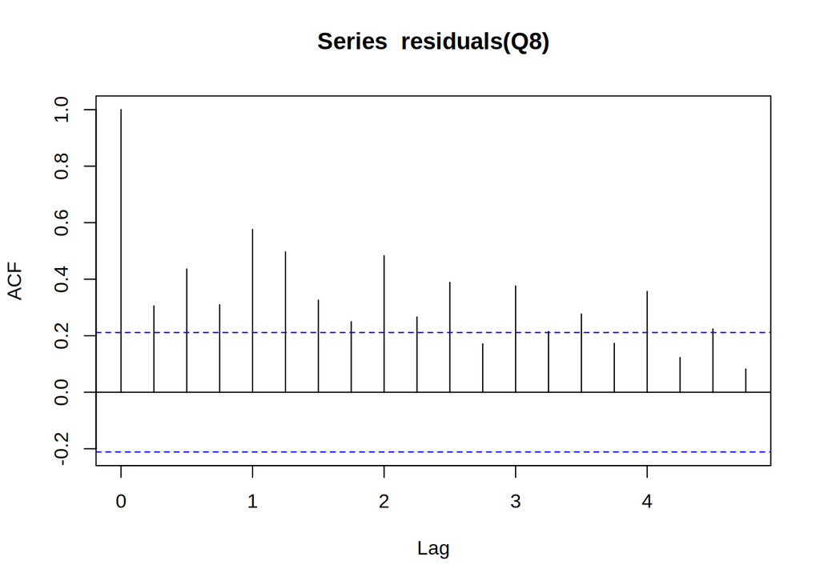

```r
acf(residuals(Q8))
```

## Non-Seasonal ARIMA [10-11]

**10. Use the “auto.arima” function to determine the best ARIMA(p,d,q) model for the data. To get auto.arima to match the results of the “arima” function, use the appropriate values of the “d=…” option and “seasonal=…” option, plus these options: ic=“aic”, approximation=FALSE, trace=TRUE, stepwise=FALSE, and method=“ML”. Report the order (p,d,q), the values of all coefficients, and the AIC for the best model.**

```r
Q10 <- auto.arima(realgdp.ts,
  d = 1,
  seasonal = FALSE,
  ic = "aic",
  approximation = FALSE,
  trace = TRUE,
  stepwise = FALSE,
  method = "ML"
)
```

```
##
##  ARIMA(0,1,0)                              : 1071.392
##  ARIMA(0,1,0)           with drift         : 1070.385
##  ARIMA(0,1,1)                              : 1057.917
##  ARIMA(0,1,1)           with drift         : 1042.497
##  ARIMA(0,1,2)                              : 1059.9
##  ARIMA(0,1,2)           with drift         : 1044.273
##  ARIMA(0,1,3)                              : 1058.502
##  ARIMA(0,1,3)           with drift         : 1045.829
##  ARIMA(0,1,4)                              : 1040.456
##  ARIMA(0,1,4)           with drift         : 1032.428
##  ARIMA(0,1,5)                              : 1042.05
##  ARIMA(0,1,5)           with drift         : 1029.807
##  ARIMA(1,1,0)                              : 1062.226
##  ARIMA(1,1,0)           with drift         : 1058.027
##  ARIMA(1,1,1)                              : 1059.906
##  ARIMA(1,1,1)           with drift         : 1044.329
##  ARIMA(1,1,2)                              : Inf
##  ARIMA(1,1,2)           with drift         : 1046.243
##  ARIMA(1,1,3)                              : Inf
##  ARIMA(1,1,3)           with drift         : Inf
##  ARIMA(1,1,4)                              : 1042.244
##  ARIMA(1,1,4)           with drift         : Inf
##  ARIMA(2,1,0)                              : 1061.812
##  ARIMA(2,1,0)           with drift         : 1054.375
##  ARIMA(2,1,1)                              : 1061.152
##  ARIMA(2,1,1)           with drift         : 1045.048
##  ARIMA(2,1,2)                              : 1046.545
##  ARIMA(2,1,2)           with drift         : 1040.939
##  ARIMA(2,1,3)                              : Inf
##  ARIMA(2,1,3)           with drift         : Inf
##  ARIMA(3,1,0)                              : 1045.305
##  ARIMA(3,1,0)           with drift         : 1017.49
##  ARIMA(3,1,1)                              : Inf
##  ARIMA(3,1,1)           with drift         : Inf
##  ARIMA(3,1,2)                              : Inf
##  ARIMA(3,1,2)           with drift         : Inf
##  ARIMA(4,1,0)                              : 1013.941
##  ARIMA(4,1,0)           with drift         : 1005.149
##  ARIMA(4,1,1)                              : 1015.69
##  ARIMA(4,1,1)           with drift         : 1006.993
##  ARIMA(5,1,0)                              : 1015.648
##  ARIMA(5,1,0)           with drift         : 1006.882
##
##
##
##  Best model: ARIMA(4,1,0)           with drift
```

**Report the order (p,d,q), the values of all coefficients, and the AIC for the best model.**  
A: The order is {4,1,0} with drift and the aic is 1005.15  
See full results below:

```r
Q10
```

```
## Series: realgdp.ts
## ARIMA(4,1,0) with drift
##
## Coefficients:
##           ar1      ar2      ar3     ar4    drift
##       -0.4096  -0.3314  -0.3520  0.3950  23.3635
## s.e.   0.0991   0.1003   0.1005  0.0989   5.2713
##
## sigma^2 = 7180:  log likelihood = -496.57
## AIC=1005.15   AICc=1006.23   BIC=1019.8
```

**11. Analyze the correlogram of the residuals for the best version of the model from #10**  
*A: The correlogram falls immediately, only with spikes at lag 1 and lag 2.*

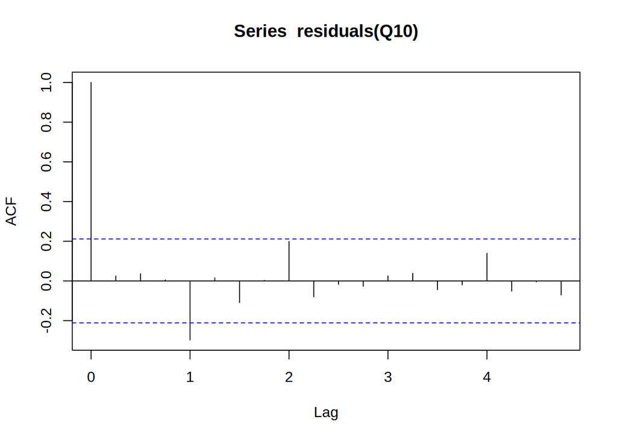

```r
acf(residuals(Q10))
```

## Seasonal ARIMA [12-16]

```r
Q12 <- arima(realgdp.ts, order = c(0, 1, 0), method = "ML")
Q12
```

```
##
## Call:
## arima(x = realgdp.ts, order = c(0, 1, 0), method = "ML")
##
##
## sigma^2 estimated as 17038:  log likelihood = -534.7,  aic = 1071.39
```

13. Use the “arima” function to fit an ARIMA(1,0,0)(2,1,0) 4 model to the data.  
Report values of all coefficients and the AIC for the model.

```r
Q13 <- arima(realgdp.ts,
  order = c(1, 0, 0),
  seasonal = list(
    order = c(2, 1, 0),
    period = 4),
  method = "ML"
)
```

**Report values of all coefficients and the AIC for the model.**  
A: The aic is 953.27.  
Full results below:

```r
Q13
```

```
##
## Call:
## arima(x = realgdp.ts, order = c(1, 0, 0), seasonal = list(order = c(2, 1, 0),
##     period = 4), method = "ML")
##
## Coefficients:
##          ar1     sar1     sar2
##       0.9485  -0.7333  -0.3066
## s.e.  0.0386   0.1114   0.1161
##
## sigma^2 estimated as 5698:  log likelihood = -472.63,  aic = 953.27
```

14.Use the “auto.arima” function to determine the best ARIMA(p,d,q)(P,D,Q)4 model for the data. To get auto.arima to match the results of the “arima” function, use the appropriate values of the “d=…” option and “seasonal=…” option, plus these options: ic=“aic”, approximation=FALSE, trace=TRUE, stepwise=FALSE, and method=“ML”.  
Report the order (p,d,q)(P,D,Q)4 , the values of all coefficients, and the AIC for the best model.

```r
Q14 <- auto.arima(realgdp.ts,
  d = 1,
  seasonal = TRUE,
  ic = "aic",
  approximation = FALSE,
  trace = TRUE,
  stepwise = FALSE,
  method = "ML"
)
```

```
##
##  ARIMA(0,1,0)(0,1,0)[4]                    : 976.9109
##  ARIMA(0,1,0)(0,1,1)[4]                    : 927.631
##  ARIMA(0,1,0)(0,1,2)[4]                    : 927.7754
##  ARIMA(0,1,0)(1,1,0)[4]                    : 947.3386
##  ARIMA(0,1,0)(1,1,1)[4]                    : 927.9169
##  ARIMA(0,1,0)(1,1,2)[4]                    : Inf
##  ARIMA(0,1,0)(2,1,0)[4]                    : 940.3789
##  ARIMA(0,1,0)(2,1,1)[4]                    : 929.872
##  ARIMA(0,1,0)(2,1,2)[4]                    : 931.6871
##  ARIMA(0,1,1)(0,1,0)[4]                    : 976.2268
##  ARIMA(0,1,1)(0,1,1)[4]                    : 927.1056
##  ARIMA(0,1,1)(0,1,2)[4]                    : 927.4308
##  ARIMA(0,1,1)(1,1,0)[4]                    : 946.0684
##  ARIMA(0,1,1)(1,1,1)[4]                    : 927.4488
##  ARIMA(0,1,1)(1,1,2)[4]                    : 929.2422
##  ARIMA(0,1,1)(2,1,0)[4]                    : 939.4995
##  ARIMA(0,1,1)(2,1,1)[4]                    : 929.4487
##  ARIMA(0,1,1)(2,1,2)[4]                    : 931.097
##  ARIMA(0,1,2)(0,1,0)[4]                    : Inf
##  ARIMA(0,1,2)(0,1,1)[4]                    : 927.431
##  ARIMA(0,1,2)(0,1,2)[4]                    : 927.936
##  ARIMA(0,1,2)(1,1,0)[4]                    : 947.5606
##  ARIMA(0,1,2)(1,1,1)[4]                    : 927.9801
##  ARIMA(0,1,2)(1,1,2)[4]                    : 929.8439
##  ARIMA(0,1,2)(2,1,0)[4]                    : 940.7876
##  ARIMA(0,1,2)(2,1,1)[4]                    : 929.9763
##  ARIMA(0,1,3)(0,1,0)[4]                    : Inf
##  ARIMA(0,1,3)(0,1,1)[4]                    : 929.3599
##  ARIMA(0,1,3)(0,1,2)[4]                    : 929.9338
##  ARIMA(0,1,3)(1,1,0)[4]                    : 948.5301
##  ARIMA(0,1,3)(1,1,1)[4]                    : 929.9734
##  ARIMA(0,1,3)(2,1,0)[4]                    : 942.3662
##  ARIMA(1,1,0)(0,1,0)[4]                    : 976.3085
##  ARIMA(1,1,0)(0,1,1)[4]                    : 927.721
##  ARIMA(1,1,0)(0,1,2)[4]                    : 928.0744
##  ARIMA(1,1,0)(1,1,0)[4]                    : 946.4859
##  ARIMA(1,1,0)(1,1,1)[4]                    : 928.1165
##  ARIMA(1,1,0)(1,1,2)[4]                    : 929.9302
##  ARIMA(1,1,0)(2,1,0)[4]                    : 940.0122
```

[output cut: 36 more lines]

```
##  ARIMA(2,1,3)(0,1,0)[4]                    : Inf
##  ARIMA(3,1,0)(0,1,0)[4]                    : 980.1039
##  ARIMA(3,1,0)(0,1,1)[4]                    : 930.0961
##  ARIMA(3,1,0)(0,1,2)[4]                    : 929.7805
##  ARIMA(3,1,0)(1,1,0)[4]                    : 949.973
##  ARIMA(3,1,0)(1,1,1)[4]                    : 929.8559
##  ARIMA(3,1,0)(2,1,0)[4]                    : 942.9326
##  ARIMA(3,1,1)(0,1,0)[4]                    : Inf
##  ARIMA(3,1,1)(0,1,1)[4]                    : 931.0618
##  ARIMA(3,1,1)(1,1,0)[4]                    : Inf
##  ARIMA(3,1,2)(0,1,0)[4]                    : Inf
##
##
##
##  Best model: ARIMA(1,1,1)(0,1,1)[4]
```

**Report the order (p,d,q)(P,D,Q)4 , the values of all coefficients, and the AIC for the best model.**  
A: The order is {1,1,1}{0,1,1} and the aic is 927.08.  
Full results below:

```r
Q14
```

```
## Series: realgdp.ts
## ARIMA(1,1,1)(0,1,1)[4]
##
## Coefficients:
##          ar1      ma1     sma1
##       0.5514  -0.7592  -0.8603
## s.e.  0.2641   0.2156   0.0783
##
## sigma^2 = 4780:  log likelihood = -459.54
## AIC=927.08   AICc=927.61   BIC=936.66
```

**15. Analyze the correlogram of the residuals for the best version of the model from #14.**  
*A: This correlogram is very good, there are no periods that get close to exceeding the threshold.*

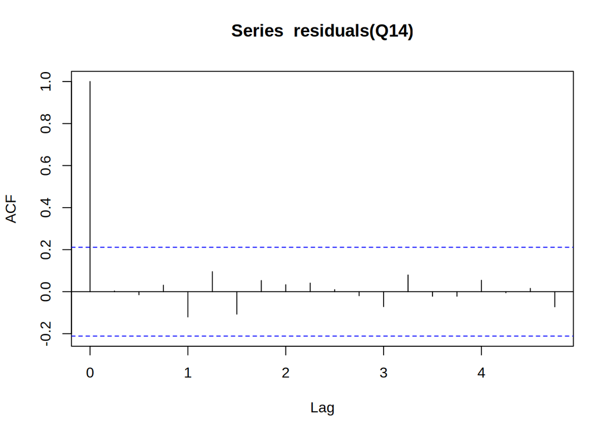

```r
acf(residuals(Q14))
```

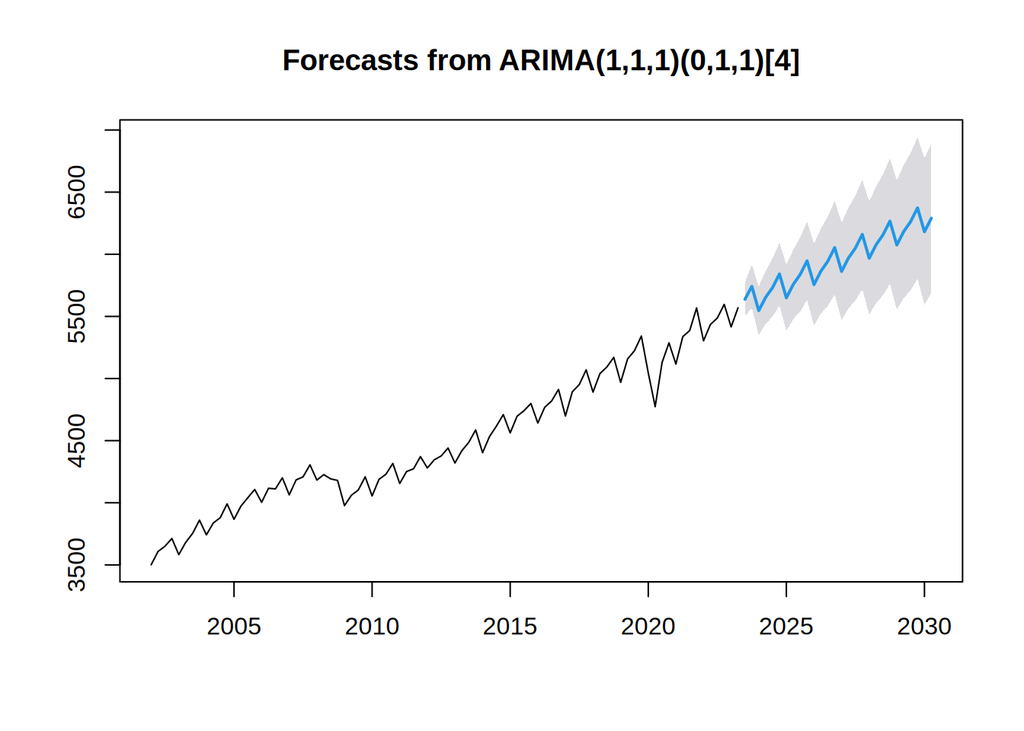

```r
plot(forecast(Q14, h = 28, level = 95))
```

## Misc [17]

**17. Using the Air Passengers series that we have used previously (accessible using data(“AirPassengers”)), demonstrate using log transformation and differencing how it can be transformed into a series that is both mean and variance stationary.**

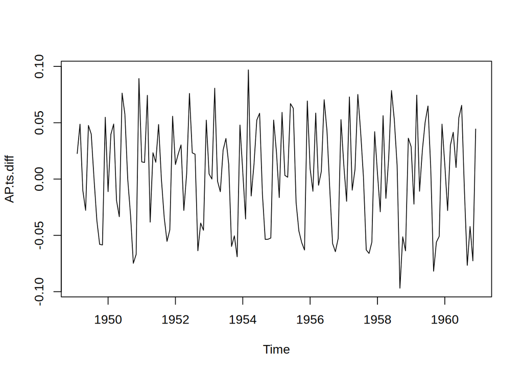

```r
AP <- AirPassengers

AP.ts <- ts(AP, start = c(1949, 1), frequency = 12)

log_AP.ts <- log10(AP.ts)

AP.ts.diff <- diff(log_AP.ts, differences = 1)

plot(AP.ts.diff)
```